# IsoFrag Phytol – Comparative Isotopomics Workflow

Merve Tomečková Öztoprak

2026-02-17

### Background

This R Markdown document reproduces the isotope ratio analysis of fragments of **Phytol** generated from the **M+1 ion beam** in an **MS² experiment** (HCD fragmentation) using an Orbitrap Mass Spectrometer.

Phytol was infused under constant flow with sufficient equilibration prior to acquisition.  
Raw Orbitrap files must be converted to **IsoX (.isox)** format before analysis.

Functions are adapted from and conceptually based on the R package **isoorbi**.  
For more information see: https://isoorbi.isoverse.org

This document performs:

1. MS1 M+1 precursor reconstruction
2. MS2 fragment ρ¹³C determination
3. Hydrogen correction using MS1-derived precursor
4. Sample vs. standard comparison
5. Heterogeneous vs homogeneous carbon model comparison
6. Variance partitioning analysis

### Project Structure

Place this Rmd file in your project root folder.

This R Markdown file combines MS1 and MS2 phytol isotomics analysis workflows. The folder structure required is:

```
project/
├── IsoFrag_Phytol.Rmd
├── InputMS1/
│   └── *.isox files
├── InputMS2/
│   └── *.isox files
├── dependencies/
│   ├── customfunctions.R
│   ├── isotopologs.tsv
│   └── sample_info.csv
└── output/
    (generated files)
```

All output files are saved to the `output/` directory. Visualizations for precision comparisons, 2H correction comparisons, and day-to-day variability are displayed in the notebook but not saved automatically.

All paths are relative and GitHub-compatible.

## 1. Package Management

This section loads all required packages for the analysis.

```r
required_packages <- c(
  "plyr", "dplyr", "ggplot2", "tidyverse", "cowplot", "data.table",
  "ggExtra", "gridExtra", "isoorbi", "scales", "readxl", "openxlsx",
  "forstringr", "purrr", "utils", "rlang", "vegan", "corrr",
  "ggcorrplot", "ggbiplot", "ComplexHeatmap", "circlize", "RColorBrewer",
  "ggforce", "corrplot", "factoextra", "FactoMineR", "gt", "minpack.lm",
  "nnet", "car", "lmtest", "lme4"
)

# Function to load/install packages
load_packages <- function(packages) {
  lapply(packages, function(x) {
    if (!require(x, character.only = TRUE)) {
      install.packages(x, dependencies = TRUE, repos = "http://cran.us.r-project.org")
      library(x, character.only = TRUE)
    }
  })
  invisible()
}

load_packages(required_packages)
```

## 2. Custom Functions

All custom functions are sourced from the dependencies folder.

```r
source("dependencies/customfunctions.R")
```

## 3. Data Import Functions

Helper functions for importing and processing raw data.

```r
# Import MS1 or MS2 .isox files
import_data <- function(filepath) {
  raw.files <- tibble(filepath = list.files(filepath, pattern = "*.isox", full.names = TRUE))

  raw.files %>%
    mutate(filename = trimws(filepath, whitespace = ".*\\/")) %>%
    relocate(filename) %>%
    rowwise() %>%
    do(., orbi_read_isox(file = .$filepath))
}

# Generate summary statistics for raw data
process_raw_data <- function(raw.data) {
  raw.data %>%
    rename(isotopolog = isotopocule) %>%
    group_by(filename) %>%
    summarise(
      no.scans = length(unique(scan.no)),
      time = max(time.min),
      compound = length(unique(compound)),
      isotopolog = length(unique(isotopolog)),
      m.resolution = mean(resolution),
      m.microscans = mean(microscans),
      m.AGC = mean(agcTarget)
    )
}
```

## 4. MS1 Data Processing

### 4.1 Import MS1 Data

```r
# Import sample information
sample_info <- read.csv("dependencies/sample_info.csv", header = TRUE, sep = ",")

# Import MS1 data
ms1_raw <- import_data("InputMS1")

# Resolve 17O/13C overlap (keep 13C, drop 17O duplicate)
ms1_raw <- ms1_raw %>%
  group_by(filename, scan.no, compound) %>%
  arrange(isotopocule, .by_group = TRUE) %>%
  filter(!(isotopocule == "17O" & duplicated(intensity) & duplicated(mzMeasured))) %>%
  ungroup()

# Merge with theoretical masses
main_mz_ms1 <- read.table("dependencies/isotopologs.tsv", header = FALSE)
colnames(main_mz_ms1) <- c("compound", "isotopocule", "m_z", "tolerance [mmu]", "z")
ms1_raw <- merge(ms1_raw, main_mz_ms1[, 1:3], by = c("compound", "isotopocule"))

# MS1 summary statistics
ms1_summary <- process_raw_data(ms1_raw)
```

### 4.2 MS1 Quality Control

```r
# Filter relevant isotopocules
ms1_filtered <- ms1_raw %>%
  filter(isotopocule %in% c("M0", "13C", "2H", "17O"))

# Flag outliers, mass defects, and weak isotopocules
ms1_flagged <- ms1_filtered %>%
  orbi_flag_outliers_new(agc_sd_cutoff = 3) %>%
  orbi_flag_mass.def_peaks() %>%
  orbi_flag_weak_isotopocules(min_percent = 90)

# Generate metadata flags
ms1_meta <- ms1_flagged %>%
  group_by(filename, compound, isotopocule) %>%
  mutate(max.scan.no = max(scan.no)) %>%
  summarize(
    prcnt.TIC = sum(intensity) / sum(tic) * 100,
    prcnt.outlier = length(which(is_outlier == TRUE)) / n() * 100,
    prcnt.satellite = length(which(is_main_mz == FALSE)) / n() * 100,
    prcnt.coverage = length(unique(scan.no)) / mean(max.scan.no) * 100
  ) %>%
  ungroup()

# Apply final filtering
ms1_clean <- ms1_flagged %>%
  filter(is_main_mz == TRUE, is_outlier == FALSE, is_weak_isotopocule == FALSE) %>%
  group_by(filename, compound, scan.no) %>%
  filter(any(isotopocule == "M0")) %>%
  ungroup() %>%
  group_by(filename, compound, isotopocule, scan.no) %>%
  filter(ions.incremental == max(ions.incremental)) %>%
  ungroup()
```

### 4.3 MS1 Abundance Calculations

```r
# Calculate Nio values
ms1_dataset <- ms1_clean %>%
  filter(isotopocule %in% c("13C", "M0", "2H", "17O")) %>%
  droplevels() %>%
  mutate(
    element = case_when(
      isotopocule == "M0" ~ "U",
      isotopocule == "13C" ~ "C",
      isotopocule == "2H" ~ "H",
      isotopocule == "17O" ~ "O",
      TRUE ~ str_extract(isotopocule, "(?<=\\d)[A-Za-z]+")
    ),
    Nio = ((intensity / peakNoise) * (4.4 / 1)) *
          ((120000 / resolution)^0.5) * (microscans^0.5)
  ) %>%
  select(filename, compound, element, isotopocule, scan.no, Nio)

# Calculate mean Nio values per file and compound
ms1_means <- ms1_dataset %>%
  group_by(filename, compound) %>%
  summarise(
    m.M0.Nio = mean(Nio[isotopocule == "M0"], na.rm = TRUE),
    ae.M0.Nio = (sd(Nio[isotopocule == "M0"], na.rm = TRUE) /
                  sqrt(sum(isotopocule == "M0"))) *
                 (1 / mean(Nio[isotopocule == "M0"], na.rm = TRUE)),
    m.M1.Nio = mean(Nio[isotopocule == "13C"], na.rm = TRUE),
    ae.M1.Nio = (sd(Nio[isotopocule == "13C"], na.rm = TRUE) /
                  sqrt(sum(isotopocule == "13C"))) *
                 (1 / mean(Nio[isotopocule == "13C"], na.rm = TRUE)),
    .groups = "drop"
  ) %>%
  complete(filename, compound)
```

### 4.4 Theoretical MS1 Calculations

```r
# Constants
VPDB <- 0.011113
SMOW17O <- 0.0003799
SMOW18O <- 0.0020672
SMOW2H <- 0.00015575

# Merge with sample information
ms1_theory <- merge(
  ms1_means %>% filter(compound == "C20H39O"),
  sample_info[, c("filename", "deltaC", "deltaH", "deltaO", "deltaAPCI", "deltaOH")],
  by = "filename"
) %>%
  mutate(
    n.C = as.numeric(str_extract(compound, "(?<=C)\\d+")),
    n.H = as.numeric(str_extract(compound, "(?<=H)\\d+")),
    n.O = ifelse(str_detect(compound, "O"), 1, 0),

    # Isotope ratios
    R.13C = VPDB * (1 + deltaC / 1000),
    R.2H = SMOW2H * (1 + deltaH / 1000),
    R.17O = SMOW17O * (1 + deltaO / 1000),
    R.APCI = SMOW2H * (1 + deltaAPCI / 1000),
    R.OH = SMOW2H * (1 + deltaOH / 1000),

    # Theoretical M+1 probabilities
    U.M1.theory.C20H40O = 20 * R.13C + 39 * R.2H + 1 * R.OH + 1 * R.17O,
    U.M1.theory.C20H39O = 20 * R.13C + 37 * R.2H + 1 * R.APCI + 1 * R.OH + 1 * R.17O,

    # Observed MS1 M+1 abundance
    U.M1.MS1 = m.M1.Nio / m.M0.Nio,
    se.U.M1.MS1 = U.M1.MS1 * sqrt(ae.M1.Nio^2 + ae.M0.Nio^2),

    # Diagnostic difference
    delta.U.M1.C20H39O = abs(U.M1.MS1 - U.M1.theory.C20H39O)
  )
```

### 4.5 MS1 Final Table

```r
# Create and save the all.table needed for MS2 analysis
all.table <- ms1_theory %>%
  select(
    filename, compound, deltaC, deltaH, R.13C, R.2H, R.17O, R.APCI, R.OH,
    U.M1.theory.C20H40O, U.M1.theory.C20H39O, U.M1.MS1, se.U.M1.MS1, delta.U.M1.C20H39O
  )%>%
  mutate(ID = case_when(
    filename == "H2210022" ~ "STD",
    filename == "H2210033" ~ "CHLA",
    TRUE ~ "Spinach" # Default value if no condition is met
  ))

write.xlsx(all.table, "output/table.MS1.xlsx")
```

## 5. MS2 Data Processing

### 5.1 Import MS2 Data

```r
# Import MS2 data
ms2_raw <- import_data("InputMS2")

# Merge with theoretical masses
main_mz_ms2 <- read.table("dependencies/isotopologs.tsv", header = FALSE)
colnames(main_mz_ms2) <- c("compound", "isotopocule", "m_z", "tolerance [mmu]", "z")
ms2_raw <- merge(ms2_raw, main_mz_ms2[, 1:3], by = c("compound", "isotopocule"))

# MS2 summary statistics
ms2_summary <- process_raw_data(ms2_raw)
```

### 5.2 MS2 Quality Control

```r
# Filter isotopocules and compounds
ms2_filtered <- ms2_raw %>%
  filter(isotopocule %in% c("M0", "13C", "2H")) %>%
  filter(!compound %in% c("C20H37", "C20H39O", "C20H40O"))

# Flag outliers, mass defects, and weak isotopocules
ms2_flagged <- ms2_filtered %>%
  orbi_flag_outliers_new(agc_sd_cutoff = 3) %>%
  orbi_flag_mass.def_peaks() %>%
  orbi_flag_weak_isotopocules(min_percent = 90)

# Apply filtering criteria
ms2_clean <- ms2_flagged %>%
  filter(
    is_outlier == FALSE,
    is_weak_isotopocule == FALSE | !isotopocule %in% c("M0")
  ) %>%
  group_by(filename, compound, scan.no) %>%
  filter(any(isotopocule == "M0")) %>%
  ungroup() %>%
  group_by(filename, compound, isotopocule, scan.no) %>%
  slice_max(ions.incremental, n = 1, with_ties = FALSE) %>%
  ungroup() %>%
  filter(!compound %in% c("C20H37", "C20H39O", "C20H40O"))
```

### 5.3 MS2 Quality Control Metadata

```r
# Generate metadata flags for supplementary tables
meta.flag.data <- ms2_flagged %>%
  group_by(filename, compound, isotopocule) %>%
  summarize(
    n = n(),
    prcnt.TIC = sum(intensity) / sum(tic) * 100,
    prcnt.outlier = length(which(is_outlier == TRUE)) / n() * 100,
    prcnt.satellite = length(which(is_main_mz == FALSE)) / n() * 100,
    prcnt.coverage = length(unique(scan.no)) / max(scan.no) * 100,
    .groups = "drop"
  )

meta.flag.data$isotopocule <- factor(meta.flag.data$isotopocule,
                                      levels = c("M0", "13C", "2H"))

# Supplementary Table 1 (oxygenated fragments)
sup.tab.1 <- meta.flag.data %>%
  merge(., sample_info[, 1:3], by = "filename") %>%
  filter(filename %in% c("H2210046"), grepl("O", compound)) %>%
  distinct() %>%
  pivot_wider(
    names_from = isotopocule,
    values_from = c(prcnt.TIC, prcnt.outlier, prcnt.satellite, prcnt.coverage),
    names_sep = "."
  ) %>%
  group_by(filename, ID, compound) %>%
  summarise(across(where(is.numeric), \(x) mean(x, na.rm = TRUE)), .groups = "drop") %>%
  mutate(across(where(is.numeric), ~ round(.x, 2)))

# Supplementary Table 2 (non-oxygenated fragments)
sup.tab.2 <- meta.flag.data %>%
  merge(., sample_info[, 1:3], by = "filename") %>%
  filter(filename %in% c("H2210046"), !grepl("O", compound)) %>%
  distinct() %>%
  pivot_wider(
    names_from = isotopocule,
    values_from = c(prcnt.TIC, prcnt.outlier, prcnt.satellite, prcnt.coverage),
    names_sep = "."
  ) %>%
  group_by(filename, ID, compound) %>%
  summarise(across(where(is.numeric), \(x) mean(x, na.rm = TRUE)), .groups = "drop") %>%
  mutate(across(where(is.numeric), ~ round(.x, 2)))

# Coverage table
coverage <- meta.flag.data %>%
  merge(., sample_info[, 1:3], by = "filename") %>%
  filter(!compound %in% c("C20H37", "C20H39O", "C20H40O")) %>%
  distinct() %>%
  pivot_wider(
    names_from = isotopocule,
    values_from = c(prcnt.TIC, prcnt.outlier, prcnt.satellite, prcnt.coverage),
    names_sep = "."
  ) %>%
  group_by(filename, compound) %>%
  summarise(across(where(is.numeric), \(x) mean(x, na.rm = TRUE)), .groups = "drop")

# Save supplementary tables
write.xlsx(sup.tab.1, "output/sup.tab.1.xlsx")
write.xlsx(sup.tab.2, "output/sup.tab.2.xlsx")
```

### 5.4 MS2 Abundance Calculations

```r
# Calculate Nio values and extract carbon/hydrogen numbers
ms2_dataset <- ms2_clean %>%
  mutate(
    element = str_extract(isotopocule, "(?<=\\d)\\p{L}+"),
    Nio = ((intensity / peakNoise) * (4.4 / 1)) *
          ((120000 / resolution)^0.5) * (microscans^0.5),
    n.C = as.numeric(str_extract(compound, "(?<=C)\\d+")),
    n.H = as.numeric(str_extract(compound, "(?<=H)\\d+"))
  ) %>%
  select(filename, compound, n.C, n.H, isotopocule, scan.no, Nio)

# Naive approach (treat missing 2H as 0)
data_ro.naive <- ms2_dataset %>%
  complete(nesting(filename, compound, scan.no), isotopocule,
           fill = list(Nio = NA), explicit = FALSE) %>%
  group_by(filename, compound, isotopocule) %>%
  split(.$isotopocule) %>%
  as.data.frame() %>%
  rename(filename = M0.filename, compound = M0.compound, scan.no = M0.scan.no) %>%
  select(filename, compound, scan.no, ends_with(".Nio")) %>%
  mutate(
    ro_denom.sum = rowSums(select(., ends_with(".Nio")), na.rm = TRUE),
    ro.13C = X13C.Nio / ro_denom.sum,
    ro.2H = X2H.Nio / ro_denom.sum,
    ro.M0 = M0.Nio / ro_denom.sum,
    ro.13C.noH = X13C.Nio / (X13C.Nio + M0.Nio)
  ) %>%
  group_by(filename, compound) %>%
  mutate(
    shotnoise.H = ((sum(na.omit(M0.Nio)) + sum(na.omit(X13C.Nio))) /
                     (sum(na.omit(X2H.Nio)) + sum(na.omit(M0.Nio)) + sum(na.omit(X13C.Nio)))) *
      sqrt((1 / sum(na.omit(X2H.Nio))) + (1 / (sum(na.omit(M0.Nio)) + sum(na.omit(X13C.Nio))))),
    shotnoise.C = ((sum(na.omit(M0.Nio)) + sum(na.omit(X2H.Nio))) /
                     (sum(na.omit(X13C.Nio)) + sum(na.omit(M0.Nio)) + sum(na.omit(X2H.Nio)))) *
      sqrt((1 / sum(na.omit(X13C.Nio))) + (1 / (sum(na.omit(M0.Nio)) + sum(na.omit(X2H.Nio)))))
  ) %>%
  ungroup()
```

### 5.5 MS2 Statistics

```r
# Calculate summary statistics
calculate_stats <- function(data, method_name, iso_pattern = "ro.", elements = c("M0", "13C", "2H")) {
  # Validate inputs
  stopifnot(is.data.frame(data))
  stopifnot(is.character(method_name), length(method_name) == 1)

  # Process data
  result <- data %>%
    group_by(filename, compound, shotnoise.H, shotnoise.C) %>%
    summarise(
      method = method_name,
      across(starts_with(iso_pattern),
             list(
               m = ~ mean(.x, na.rm = TRUE),
               sd = ~ sd(.x, na.rm = TRUE),
               se = ~ sd(.x, na.rm = TRUE) / sqrt(n()),
               ae = ~ (sd(.x, na.rm = TRUE) / sqrt(n())) * (1 / mean(.x, na.rm = TRUE))
             ),
             .names = "{col}.{.fn}"
      ),
      .groups = "drop"
    ) %>%
    mutate(
      across(where(is.numeric), ~ ifelse(is.nan(.), NA, .)),
      sum.ro = rowSums(across(ends_with(".m")), na.rm = TRUE),
      SNL.H.test = ifelse((ro.2H.ae / shotnoise.H) < 2, "pass", "fail"),
      SNL.C.test = ifelse((ro.13C.ae / shotnoise.C) < 2, "pass", "fail"),
      n.C = as.numeric(str_extract(compound, "(?<=C)\\d+")),
      n.H = as.numeric(str_extract(compound, "(?<=H)\\d+")),
      n.O = case_when(
        str_detect(compound, "O\\d+") ~ as.numeric(str_extract(compound, "(?<=O)\\d+")),
        str_detect(compound, "O") ~ 1,
        TRUE ~ 0
      )
    ) %>%
    filter(!sum.ro == 0)

  return(result)
}

# Calculate s_ro.naive if not already done
s_ro.naive <- calculate_stats(data_ro.naive, "naive")
```

### 5.6 Shot noise limit check of individual fragments

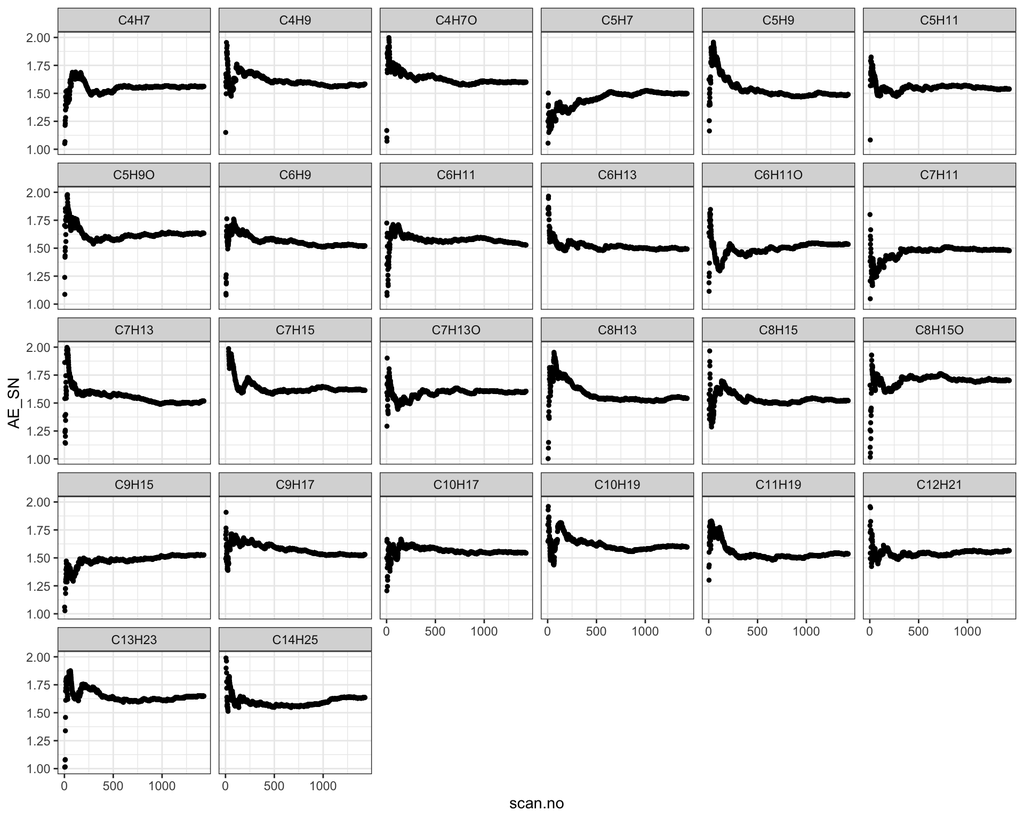

```r
# AE/SNL comparison
comp.ae_SNL <- data_ro.naive %>%
  filter(filename == "H2210046") %>%
  filter(!compound %in% c("C8H17", "C9H19", "C11H21", "C12H23", "C13H25",
                          "C14H27", "C9H17O", "C20H37", "C20H39O", "C20H40O")) %>%
  arrange(compound, scan.no) %>%
  group_by(compound) %>%
  mutate(
    cum_M0 = cumsum(replace_na(M0.Nio, 0)),
    cum_13C = cumsum(replace_na(X13C.Nio, 0)),
    cum_2H = cumsum(replace_na(X2H.Nio, 0)),
    n_scan = row_number(),
    shotnoise.C_cum = if_else(cum_13C > 0 & (cum_M0 + cum_2H) > 0,
                              ((cum_M0 + cum_2H) / (cum_M0 + cum_13C + cum_2H)) *
                                sqrt(1 / cum_13C + 1 / (cum_M0 + cum_2H)),
                              NA_real_),
    mean_13C_cum = map_dbl(n_scan, ~ mean(ro.13C[1:.x], na.rm = TRUE)),
    sd_13C_cum = map_dbl(n_scan, ~ ifelse(.x > 1, sd(ro.13C[1:.x], na.rm = TRUE), NA_real_)),
    ae_13C_cum = if_else(n_scan > 1 & mean_13C_cum > 0,
                         (sd_13C_cum / sqrt(n_scan)) * (1 / mean_13C_cum),
                         NA_real_),
    AE_SN = ae_13C_cum / shotnoise.C_cum
  ) %>%
  ungroup()

ggplot(comp.ae_SNL %>%
         mutate(C = as.integer(str_extract(compound, "(?<=C)\\d+"))) %>%
         arrange(C) %>%
         mutate(compound = factor(compound, levels = unique(compound))),
       aes(x = scan.no, y = AE_SN)) +
  geom_point(size = 1) +
  ylim(1, 2) +
  theme_bw() +
  facet_wrap(~compound)
```

### 5.7 Isotope Correction Calculations

```r
# Create theoretical table by merging with sample_info and MS1_data
ro.theory <- merge(
  s_ro.naive[, c("filename", "compound", "shotnoise.H", "shotnoise.C", "n.C", "n.H", "n.O")],
  sample_info[, c("filename", "ID", "deltaC", "deltaH", "deltaO", "deltaAPCI", "deltaOH")],
  by = "filename"
) %>%
  merge(all.table[, c("ID", "R.13C", "R.2H", "R.17O", "R.APCI", "R.OH",
                      "U.M1.theory.C20H39O", "U.M1.MS1", "se.U.M1.MS1")], by = "ID")

# Constants
R_VPDB <- 0.011113
delta.C.err <- 0.56

# Apply corrections
s_ro.corr <- s_ro.naive %>%
  # Filter unwanted compounds and files
  filter(!compound %in% c("C8H17", "C9H19", "C11H21", "C12H23", "C13H25", "C14H27", "C9H17O")) %>%
  filter(SNL.C.test == "pass") %>%
  # Merge with theoretical data (excluding columns 4:12 from ro.theory)
  merge(
    ro.theory[, !names(ro.theory) %in% names(ro.theory)[4:12]],
    by = c("filename", "compound")
  ) %>%
  # Merge with coverage data (columns 1,2,15 are filename, compound, prcnt.coverage.2H)
  merge(
    coverage[, c(1, 2, which(names(coverage) == "prcnt.coverage.2H"))],
    by = c("filename", "compound")
  ) %>%
  # Merge with sample info for date and replicate
  merge(
    sample_info[, c("filename", "date", "replicate")],
    by = "filename"
  ) %>%
  mutate(
    prcnt.coverage.2H = ifelse(is.nan(prcnt.coverage.2H) | is.na(prcnt.coverage.2H),
                                0, prcnt.coverage.2H),

    # Calculate U.M1.MS1.ae
    U_M1_MS1.ae = se.U.M1.MS1 / U.M1.MS1,

    # Hydrogen-anchored precursor reconstruction
    U.2H.f = ifelse(grepl("O", compound),
                    (n.H - 2) * R.2H + R.APCI + R.OH,
                    (n.H - 1) * R.2H + R.APCI),
    ro.2H.pred = U.2H.f / U.M1.MS1,

    # Corrected 13C abundance
    ro.13C.corr = ro.13C.noH.m * (1 - ro.2H.pred),
    ro.13C.corr.ae = ro.13C.ae,

    # Homogeneous model prediction
    ro.13C.homo = (n.C * R.13C) / U.M1.MS1,
    R.13C.err = R_VPDB * (delta.C.err / 1000),
    R.13C.ae = R.13C.err / R.13C,
    ro.13C.homo.ae = sqrt(R.13C.ae^2 + U_M1_MS1.ae^2)
  ) %>%
  mutate(
    # Determine method based on 2H coverage
    method = ifelse(prcnt.coverage.2H < 90, "exp_corr", "naive"),

    # Calculate degrees of unsaturation
    DoU = ((2 * n.C + 2) - (n.H + 1)) / 2,

    # Assign groups based on unsaturation and oxygenation
    Group = case_when(
      DoU == 0 ~ "Mono-unsaturated",
      DoU == 1 & grepl("O$", compound) ~ "Di-unsaturated (Oxygenated)",
      DoU == 1 ~ "Di-unsaturated (Non-oxygenated)",
      DoU == 2 ~ "Tri-unsaturated",
      TRUE ~ "Other"
    ),

    # Element type
    element = ifelse(grepl("O", compound), "O", "C"),

    # Final 13C value (corrected or naive based on coverage)
    ro.13C.value = ifelse(prcnt.coverage.2H < 90, ro.13C.corr, ro.13C.m),
    ro.13C.value.ae = ifelse(prcnt.coverage.2H < 90, ro.13C.corr.ae, ro.13C.ae),

    # Calculate U.13C.f (fractional abundance at carbon sites)
    U.13C.f = (ro.13C.value * U.M1.MS1) / n.C,
    U.13C.f.ae = sqrt(ro.13C.value.ae^2 + U_M1_MS1.ae^2),
    U.13C.f.se = U.13C.f * U.13C.f.ae
  )

# Check the resulting data frame
glimpse(s_ro.corr)
```

```
## Rows: 364
## Columns: 57
## $ filename            <fct> H2210023, H2210023, H2210023, H2210023, H2210023, …
## $ compound            <fct> C10H17, C10H19, C11H19, C12H21, C13H23, C14H25, C4…
## $ shotnoise.H         <dbl> 0.006271290, 0.030436294, 0.006838796, 0.020822302…
## $ shotnoise.C         <dbl> 0.0006263069, 0.0017283332, 0.0006270715, 0.000968…
## $ method              <chr> "exp_corr", "exp_corr", "exp_corr", "exp_corr", "e…
## $ ro.13C.m            <dbl> 0.4847369, 0.4322388, 0.5333731, 0.5866571, 0.6399…
## $ ro.13C.sd           <dbl> 0.017982370, 0.046557596, 0.019474938, 0.033865765…
## $ ro.13C.se           <dbl> 0.0004627628, 0.0011981248, 0.0005011729, 0.000871…
## $ ro.13C.ae           <dbl> 0.0009546681, 0.0027719051, 0.0009396293, 0.001485…
## $ ro.2H.m             <dbl> 0.012846369, 0.069041977, 0.014199723, 0.057818896…
## $ ro.2H.sd            <dbl> 0.003979103, 0.010393044, 0.003606493, 0.010528415…
## $ ro.2H.se            <dbl> 1.023992e-04, 2.674572e-04, 9.281040e-05, 2.709409…
## $ ro.2H.ae            <dbl> 0.007971065, 0.003873835, 0.006536071, 0.004686027…
```

[output cut: 44 more lines]

### 5.8 Visualizations (Display Only)

These plots are for visual inspection and will not be saved.

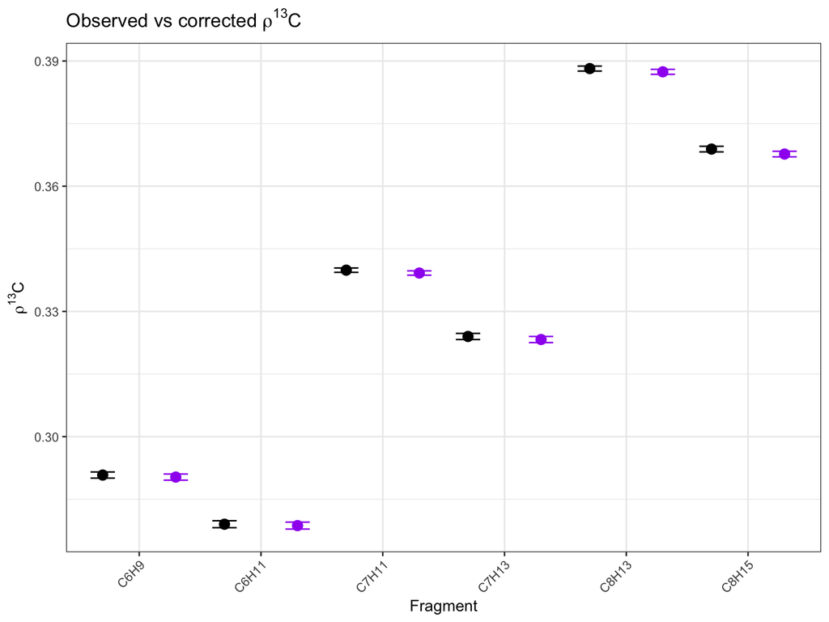

```r
# Compare 2H correction
ggplot(s_ro.corr %>% filter(filename == "H2210046", prcnt.coverage.2H >= 90),
       aes(x = compound)) +
  geom_point(aes(y = ro.13C.m), color = "black", size = 3,
             position = position_nudge(x = -0.30)) +
  geom_errorbar(aes(ymin = ro.13C.m - ro.13C.ae, ymax = ro.13C.m + ro.13C.ae),
                width = 0.2, position = position_nudge(x = -0.30)) +
  geom_point(aes(y = ro.13C.corr), color = "purple", size = 3,
             position = position_nudge(x = 0.30)) +
  geom_errorbar(aes(ymin = ro.13C.corr - ro.13C.corr.ae,
                    ymax = ro.13C.corr + ro.13C.corr.ae),
                width = 0.2, position = position_nudge(x = 0.30), color = "purple") +
  labs(title = expression("Observed vs corrected "*rho^{13}*"C"),
       x = "Fragment", y = expression(rho^{13}*C)) +
  theme_bw() +
  theme(axis.text.x = element_text(angle = 45, hjust = 1))
```

### 5.9 Precision check

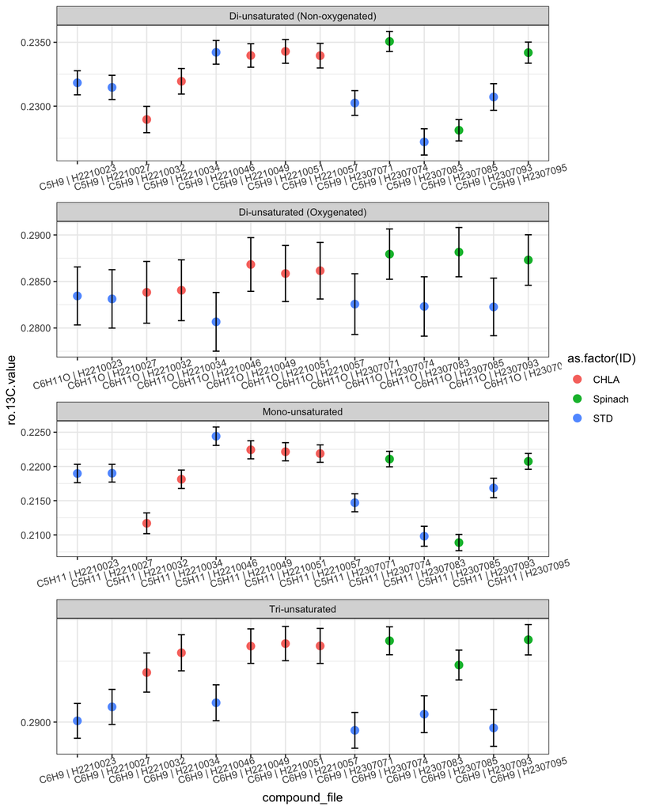

```r
# Sample-standard precision
precision_1 <- s_ro.corr %>%
  filter(compound %in% c("C6H9", "C5H9", "C6H11O", "C5H11")) %>%
  mutate(test.ae = ro.13C.value.ae * 1000) %>%
  merge(., sample_info[, c(1, 3, 4)], by = "filename") %>%
  mutate(
    compound_file = paste0(compound, " | ", filename),
    compound_file = factor(compound_file, levels = s_ro.corr %>%
                             arrange(compound, filename) %>%
                             distinct(compound, filename) %>%
                             mutate(cf = paste0(compound, " | ", filename)) %>%
                             pull(cf)),
    session = case_when(
      filename %in% c("H2210023", "H2210027", "H2210046",
                      "H2210032", "H2210034", "H2210049",
                      "H2210051", "H2210057") ~ 1,
      filename %in% c("H2307071", "H2307083", "H2307093",
                      "H2307074", "H2307085", "H2307095") ~ 2
    )
  )

ggplot(precision_1,
       aes(x = compound_file, y = ro.13C.value, colour = as.factor(ID))) +
  geom_point(size = 3) +
  geom_errorbar(aes(ymin = ro.13C.value - ro.13C.value.ae,
                    ymax = ro.13C.value + ro.13C.value.ae),
                width = 0.2, colour = "black") +
  theme_bw() +
  scale_y_continuous(
    breaks = function(limits) seq(
      from = floor(limits[1] / 0.005) * 0.005,
      to = ceiling(limits[2] / 0.005) * 0.005,
      by = 0.005
    ),
    labels = scales::number_format(accuracy = 0.0001)
  ) +
  theme(axis.text.x = element_text(angle = 15, vjust = 0.7)) +
  facet_wrap(~Group, scales = "free", nrow = 4)
```

### 5.10 Output rho Tables and Figures

```r
# Supplementary Table II
supp.II_1 <- s_ro.corr %>%
  select(filename, compound, ID, ro.13C.ae, ro.13C.value.ae, ro.13C.value, shotnoise.C) %>%
  filter(filename == "H2210046", grepl("O", compound)) %>%
  mutate(
    AE_SNL = ro.13C.value.ae / shotnoise.C,
    ae = ro.13C.value.ae * 1000
  )

supp.II_2 <- s_ro.corr %>%
  select(filename, compound, ID, ro.13C.ae, ro.13C.value.ae, ro.13C.value, shotnoise.C) %>%
  filter(filename == "H2210046", !grepl("O", compound)) %>%
  mutate(
    AE_SNL = ro.13C.value.ae / shotnoise.C,
    ae = ro.13C.value.ae * 1000
  )

write.xlsx(supp.II_1, "output/supp.II_1.xlsx")
write.xlsx(supp.II_2, "output/supp.II_2.xlsx")
```

### 5.11 Sample-STD bracketing

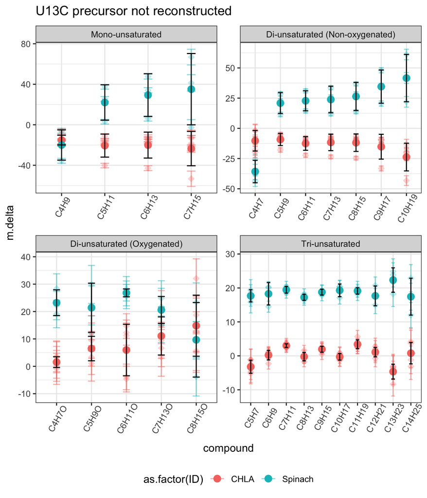

```r
# Figure 6 - Sample vs Standard comparison
comp.STD.sample <- s_ro.corr %>%
  filter(!ID == "STD") %>%
  select(filename, compound, DoU, Group, element, method, date, replicate, ID, n.C,
         ro.13C.value, ro.13C.value.ae, U.13C.f, U.13C.f.ae, U.13C.f.se) %>%
  merge(
    s_ro.corr %>% filter(ID == "STD") %>% filter(!filename == "H2210023") %>%
      select(filename, compound, date, ro.13C.value, ro.13C.value.ae, U.13C.f, U.13C.f.ae),
    by = c("date", "compound"),
    suffixes = c("", ".std")
  ) %>%
  rename(ro.13C.std = ro.13C.value.std,
         ro.13C.std.ae = ro.13C.value.ae.std) %>%
  mutate(
    ratio_to_STD = ((U.13C.f / U.13C.f.std) - 1) * 1000,
    R.ae = (U.13C.f / U.13C.f.std) * sqrt(U.13C.f.ae^2 + U.13C.f.ae.std^2),
    ratio_to_STD.ae = R.ae * 1000
  )

m.comp <- comp.STD.sample %>%
  group_by(ID, compound, Group) %>%
  summarise(
    m.delta = mean(ratio_to_STD, na.rm = TRUE),
    sd.delta = sd(ratio_to_STD, na.rm = TRUE),
    se.m.delta = sqrt(sum(ratio_to_STD.ae^2, na.rm = TRUE)) / n(),  # This was missing
    sem.delta = sd(ratio_to_STD, na.rm = TRUE) / sqrt(n()),
    count = n(),
    .groups = "drop"
  )

rep.median =comp.STD.sample%>%group_by(ID,Group)%>%
  summarise(
    median.sd=median(sd(ratio_to_STD))
  )
mol.median =m.comp%>%group_by(ID)%>%
  summarise(
    median.sd=median(m.delta)
  )

ggplot(m.comp,
       aes(x=compound,y=m.delta, colour=as.factor(ID)))+
  geom_point(data = comp.STD.sample,
             aes(x = compound, y =ratio_to_STD, colour = ID),
             size = 3, shape = 18, inherit.aes = FALSE,
             alpha = 0.3) +  # per sample/std points
  geom_errorbar(data = comp.STD.sample,
                aes(x = compound, ymin=ratio_to_STD-ratio_to_STD.ae, ymax=ratio_to_STD+ratio_to_STD.ae,colour = ID),
                inherit.aes = FALSE,width = 0.2, alpha = 0.5) +  # error bars
  geom_point(data=m.comp, size=3)+
  geom_errorbar(data=m.comp,
                aes(ymin=m.delta-sd.delta, ymax=m.delta+sd.delta), width=.2, colour="black")+
  theme_bw()+
  labs(title = expression("U13C precursor not reconstructed"))+
  theme(axis.text.x = element_text(angle = 90, vjust = 0.7))+
  facet_wrap(~ factor(Group, levels = c("Mono-unsaturated",
                                        "Di-unsaturated (Non-oxygenated)",
                                        "Di-unsaturated (Oxygenated)",
                                        "Tri-unsaturated")),
             scales = "free", nrow = 2) +
  theme(axis.text.x = element_text(angle = 60, vjust = 0.7),
        legend.position = "bottom")
```

```r
ggsave("output/fig6.pdf", width = 6, height = 7)
```

### 5.12 Sample-STD tables output

```r
# Output tables
output_table_wide <- comp.STD.sample %>%
  select(ID, compound, filename, ratio_to_STD, ratio_to_STD.ae) %>%
  group_by(compound) %>%
  mutate(replicate = as.integer(factor(filename, levels = unique(filename)))) %>%
  ungroup() %>%
  mutate(
    ratio_to_STD.ae = abs(ratio_to_STD.ae),
    formatted_value = sprintf("%.1f ± %.1f",
                              round(ratio_to_STD, 1),
                              round(ratio_to_STD.ae, 1))
  ) %>%
  mutate(compound = factor(compound,
                           levels = c("C4H7", "C4H7O", "C4H9", "C5H7", "C5H9", "C5H9O",
                                      "C5H11", "C6H9", "C6H11", "C6H11O", "C6H13",
                                      "C7H11", "C7H13", "C7H13O","C7H15", "C8H13", "C8H15", "C8H15O", "C9H15", "C9H17",
                                      "C10H17", "C10H19", "C11H19", "C12H21", "C13H23", "C14H25"))) %>%
  select(-ratio_to_STD, -ratio_to_STD.ae, -filename) %>%
  pivot_wider(
    names_from = ID,
    values_from = formatted_value,
    names_prefix = "delta_"
  ) %>%
  arrange(compound, replicate)

output_comp_wide <- m.comp %>%
  select(ID, compound, m.delta, se.m.delta, sem.delta) %>%
  ungroup() %>%
  mutate(
    sem.delta = abs(sem.delta),
    formatted_value = sprintf("%.1f ± %.1f",
                              round(m.delta, 1),
                              round(sem.delta, 1))
  ) %>%
  mutate(compound = factor(compound,
                           levels = c("C4H7", "C4H7O", "C4H9", "C5H7", "C5H9", "C5H9O",
                                      "C5H11", "C6H9", "C6H11", "C6H11O", "C6H13",
                                      "C7H11", "C7H13", "C7H13O", "C7H15", "C8H13",
                                      "C8H15", "C8H15O", "C9H15", "C9H17",
                                      "C10H17", "C10H19", "C11H19", "C12H21", "C13H23"))) %>%
  select(-m.delta, -se.m.delta, -sem.delta) %>%
  pivot_wider(
    names_from = ID,
    values_from = formatted_value,
    names_prefix = "delta_"
  ) %>%
  arrange(compound)


write.xlsx(output_table_wide, "output/output_table_wide.xlsx")
write.xlsx(output_comp_wide, "output/output_comp_wide.xlsx")

# Display first few rows to verify
print("Output Table Wide (first 20 rows):")
```

```
## [1] "Output Table Wide (first 20 rows):"
```

```r
print(head(output_table_wide, 20))
```

```
## # A tibble: 20 × 4
##    compound replicate delta_Spinach delta_CHLA
##    <fct>        <int> <chr>         <chr>
##  1 C4H7             1 -25.6 ± 4.2   <NA>
##  2 C4H7             2 -38.0 ± 4.4   <NA>
##  3 C4H7             3 <NA>          -1.7 ± 5.2
##  4 C4H7             4 <NA>          -2.1 ± 5.0
##  5 C4H7             5 -43.7 ± 4.4   <NA>
##  6 C4H7             6 <NA>          -17.9 ± 4.5
##  7 C4H7             7 <NA>          -19.7 ± 4.5
##  8 C4H7             8 <NA>          -10.0 ± 4.5
##  9 C4H7O            1 19.1 ± 5.0    <NA>
## 10 C4H7O            2 22.2 ± 5.2    <NA>
## 11 C4H7O            3 <NA>          -0.9 ± 5.7
## 12 C4H7O            4 <NA>          1.5 ± 5.8
## 13 C4H7O            5 28.4 ± 5.4    <NA>
## 14 C4H7O            6 <NA>          3.6 ± 5.6
## 15 C4H7O            7 <NA>          0.2 ± 5.6
## 16 C4H7O            8 <NA>          3.3 ± 5.7
## 17 C4H9             1 -5.9 ± 2.4    <NA>
## 18 C4H9             2 -35.6 ± 2.4   <NA>
## 19 C4H9             3 <NA>          -18.6 ± 2.7
## 20 C4H9             4 <NA>          -6.7 ± 2.6
```

```r
print("Output Compound Summary (first 20 rows):")
```

```
## [1] "Output Compound Summary (first 20 rows):"
```

```r
print(head(output_comp_wide, 20))
```

```
## # A tibble: 20 × 3
##    compound delta_CHLA  delta_Spinach
##    <fct>    <chr>       <chr>
##  1 C4H7     -10.3 ± 3.8 -35.8 ± 5.4
##  2 C4H7O    1.5 ± 0.9   23.2 ± 2.7
##  3 C4H9     -15.1 ± 2.1 -20.0 ± 8.6
##  4 C5H7     -3.2 ± 0.9  17.7 ± 1.0
##  5 C5H9     -9.2 ± 2.2  20.9 ± 5.0
##  6 C5H9O    6.5 ± 2.0   21.4 ± 5.2
##  7 C5H11    -20.6 ± 5.1 22.0 ± 10.1
##  8 C6H9     0.2 ± 0.6   18.3 ± 1.9
##  9 C6H11    -12.5 ± 2.5 22.8 ± 4.8
## 10 C6H11O   6.0 ± 4.2   26.8 ± 0.8
## 11 C6H13    -20.1 ± 5.7 29.3 ± 12.2
## 12 C7H11    3.0 ± 0.2   19.5 ± 0.6
## 13 C7H13    -11.6 ± 3.1 23.9 ± 6.3
## 14 C7H13O   11.1 ± 3.1  20.6 ± 2.8
## 15 C7H15    -23.5 ± 7.6 35.2 ± 20.3
## 16 C8H13    -0.2 ± 0.6  17.2 ± 0.5
## 17 C8H15    -11.9 ± 3.2 26.4 ± 6.7
## 18 C8H15O   14.8 ± 5.0  9.7 ± 7.9
## 19 C9H15    2.0 ± 0.4   18.8 ± 0.5
## 20 C9H17    -15.2 ± 4.6 34.5 ± 7.9
```

### 5.13 Day-to-Day Variability Analysis

```r
# Calculate daily means
daily_means <- comp.STD.sample %>%
  group_by(ID, compound, Group, date) %>%
  summarise(
    daily_mean = mean(ratio_to_STD, na.rm = TRUE),
    .groups = "drop"
  )

# Calculate between-day standard deviation
day_to_day_sd <- daily_means %>%
  group_by(ID, compound, Group) %>%
  summarise(
    sd_between_day = sd(daily_mean, na.rm = TRUE),
    n_days = n(),
    .groups = "drop"
  )

# Median between-day variability by sample type
median_sd <- day_to_day_sd %>%
  group_by(ID) %>%
  summarise(
    median.sd = median(sd_between_day, na.rm = TRUE)
  )
print("Median between-day SD by sample type:")
```

```
## [1] "Median between-day SD by sample type:"
```

```r
print(median_sd)
```

```
## # A tibble: 2 × 2
##   ID      median.sd
##   <chr>       <dbl>
## 1 CHLA         2.99
## 2 Spinach      6.85
```

```r
# Mean between-day variability by group
group_day_variability <- day_to_day_sd %>%
  group_by(ID, Group) %>%
  summarise(
    mean_between_day_sd = mean(sd_between_day, na.rm = TRUE),
    .groups = "drop"
  )
print("Mean between-day SD by fragment group:")
```

```
## [1] "Mean between-day SD by fragment group:"
```

```r
print(group_day_variability)
```

```
## # A tibble: 8 × 3
##   ID      Group                           mean_between_day_sd
##   <chr>   <chr>                                         <dbl>
## 1 CHLA    Di-unsaturated (Non-oxygenated)               5.22
## 2 CHLA    Di-unsaturated (Oxygenated)                   5.76
## 3 CHLA    Mono-unsaturated                              8.07
## 4 CHLA    Tri-unsaturated                               0.721
## 5 Spinach Di-unsaturated (Non-oxygenated)              11.7
## 6 Spinach Di-unsaturated (Oxygenated)                   6.73
## 7 Spinach Mono-unsaturated                             22.2
## 8 Spinach Tri-unsaturated                               2.26
```

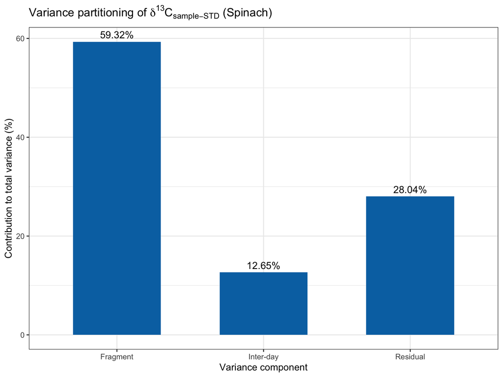

```r
# Mixed-effects model for Spinach
sp_data <- comp.STD.sample %>% filter(ID == "Spinach")
if(nrow(sp_data) > 0) {
  mod_sp <- lmer(ratio_to_STD ~ 1 + (1 | date) + (1 | compound),
                 data = sp_data, REML = TRUE)

  vc_sp <- as.data.frame(VarCorr(mod_sp)) %>%
    select(grp, vcov) %>%
    mutate(
      Component = case_when(
        grp == "date" ~ "Inter-day",
        grp == "compound" ~ "Fragment",
        grp == "Residual" ~ "Residual",
        TRUE ~ grp
      ),
      percent = 100 * vcov / sum(vcov)
    )

  # Variance partitioning plot for Spinach
  p_spinach <- ggplot(vc_sp, aes(x = Component, y = percent)) +
    geom_col(width = 0.6, fill = "#0072B2") +
    geom_text(aes(label = sprintf("%.2f%%", percent)),
              vjust = -0.5, size = 4) +
    theme_bw() +
    labs(x = "Variance component",
         y = "Contribution to total variance (%)",
         title = expression("Variance partitioning of " *
                              delta^{13} * "C"[sample-STD] * " (Spinach)"))

  print(p_spinach)
}
```

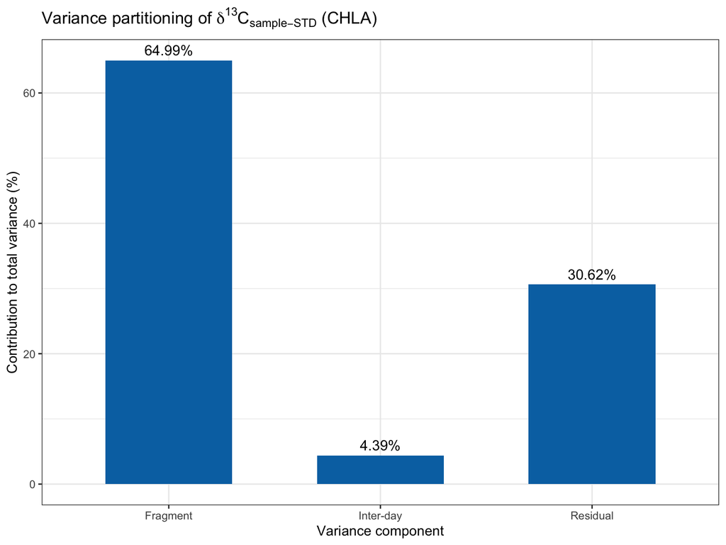

```r
# Mixed-effects model for CHLA
chla_data <- comp.STD.sample %>% filter(ID == "CHLA")
if(nrow(chla_data) > 0) {
  mod_chla <- lmer(ratio_to_STD ~ 1 + (1 | date) + (1 | compound),
                   data = chla_data, REML = TRUE)

  vc_chla <- as.data.frame(VarCorr(mod_chla)) %>%
    select(grp, vcov) %>%
    mutate(
      Component = case_when(
        grp == "date" ~ "Inter-day",
        grp == "compound" ~ "Fragment",
        grp == "Residual" ~ "Residual",
        TRUE ~ grp
      ),
      percent = 100 * vcov / sum(vcov)
    )

  # Variance partitioning plot for CHLA
  p_chla <- ggplot(vc_chla, aes(x = Component, y = percent)) +
    geom_col(width = 0.6, fill = "#0072B2") +
    geom_text(aes(label = sprintf("%.2f%%", percent)),
              vjust = -0.5, size = 4) +
    theme_bw() +
    labs(x = "Variance component",
         y = "Contribution to total variance (%)",
         title = expression("Variance partitioning of " *
                              delta^{13} * "C"[sample-STD] * " (CHLA)"))

  print(p_chla)
}
```

### 5.14 Heterogeneous vs. Homogeneous modelling

hypothesis testing of intra-molecular heterogeneity

```r
# Figure 4 - Heterogeneous vs Homogeneous Model comparison

# Fragment definitions for the model
carbon_positions <- paste0("C", 1:20)

fragment_definitions <- list(
  C4H7 = c("C16", "C15", "C14", "C20"),
  C4H9 = c("C16", "C15", "C14", "C20"),
  C4H7O = c("C1", "C2", "C3", "C17"),
  C5H7 = c("C1", "C2", "C3", "C17", "C4"),
  C5H9 = c("C16", "C15", "C14", "C20", "C13"),
  C5H11 = c("C16", "C15", "C14", "C20", "C13"),
  C5H9O = c("C1", "C2", "C3", "C17", "C4"),
  C6H9 = c("C1", "C2", "C3", "C17", "C4", "C5"),
  C6H11 = c("C16", "C15", "C14", "C20", "C13", "C12"),
  C6H13 = c("C16", "C15", "C14", "C20", "C13", "C12"),
  C6H11O = c("C1", "C2", "C3", "C17", "C4", "C5"),
  C7H11 = c("C1", "C2", "C3", "C17", "C4", "C5", "C6"),
  C7H13 = c("C16", "C15", "C14", "C13", "C12", "C11", "C20"),
  C7H15 = c("C16", "C15", "C14", "C13", "C12", "C11", "C20"),
  C7H13O = c("C1", "C2", "C3", "C17", "C4", "C5", "C6"),
  C8H13 = c("C1", "C2", "C3", "C17", "C4", "C5", "C6", "C7"),
  C8H15 = c("C16", "C15", "C14", "C13", "C12", "C11", "C19", "C20"),
  C8H15O = c("C1", "C2", "C3", "C17", "C4", "C5", "C6", "C7"),
  C9H15 = c("C1", "C2", "C3", "C17", "C4", "C5", "C6", "C7", "C18"),
  C9H17 = c("C16", "C15", "C14", "C13", "C12", "C11", "C19", "C20", "C10"),
  C10H17 = c("C1", "C2", "C3", "C17", "C4", "C5", "C6", "C7", "C18", "C8"),
  C10H19 = c("C16", "C15", "C14", "C13", "C12", "C11", "C19", "C20", "C10", "C9"),
  C11H19 = c("C1", "C2", "C3", "C17", "C4", "C5", "C6", "C7", "C18", "C8", "C9"),
  C12H21 = c("C1", "C2", "C3", "C17", "C4", "C5", "C6", "C7", "C18", "C8", "C9", "C10"),
  C13H23 = c("C1", "C2", "C3", "C17", "C4", "C5", "C6", "C7", "C18", "C8", "C9", "C10", "C11"),
  C14H25 = c("C1", "C2", "C3", "C17", "C4", "C5", "C6", "C7", "C18", "C8", "C9", "C10", "C11", "C12")
)

# Prepare observed data
observed <- s_ro.corr[, c("filename", "compound", "ro.13C.value", "ro.13C.value.ae", "ro.13C.homo", "ro.13C.homo.ae")] %>%
  merge(., sample_info[, 1:2], by = "filename")

# Function to solve for position-specific values
process_sum_model <- function(df_group, fragment_definitions) {

  observed_values <- df_group$ro.13C.value
  names(observed_values) <- df_group$compound

  ae_values <- df_group$ro.13C.value.ae
  names(ae_values) <- df_group$compound

  valid_fragments <- intersect(names(fragment_definitions), df_group$compound)
  observed_values <- observed_values[valid_fragments]
  ae_values <- ae_values[valid_fragments]
  fragment_definitions <- fragment_definitions[valid_fragments]

  A_sum <- matrix(
    0,
    nrow = length(valid_fragments),
    ncol = 20,
    dimnames = list(valid_fragments, carbon_positions)
  )

  for (fragment in valid_fragments) {
    A_sum[fragment, fragment_definitions[[fragment]]] <- 1
  }

  weights <- 1 / (ae_values^2)

  solution_sum <- lm(observed_values ~ A_sum + 0, weights = weights)

  position_specific_13C_sum <- coef(solution_sum)
  names(position_specific_13C_sum) <- carbon_positions

  V <- vcov(solution_sum)
  V[is.na(V)] <- 0

  position_specific_13C_ae <- sqrt(diag(V))
  names(position_specific_13C_ae) <- carbon_positions

  position_specific_13C_sum_noNA <- position_specific_13C_sum
  position_specific_13C_sum_noNA[is.na(position_specific_13C_sum_noNA)] <- 0

  position_specific_13C_ae_noNA <- position_specific_13C_ae
  position_specific_13C_ae_noNA[is.na(position_specific_13C_ae_noNA)] <- NA

  # Apply group constraints
  grp1 <- c("C1", "C2", "C3", "C17")
  grp2 <- c("C14", "C15", "C16", "C20")

  apply_group_constraint <- function(vals, V, grp) {
    idx <- match(grp, names(vals))
    mean_val <- mean(vals[idx])
    ae_val <- sqrt(sum(V[idx, idx]) / length(idx)^2)
    list(value = mean_val, ae = ae_val)
  }

  g1 <- apply_group_constraint(position_specific_13C_sum_noNA, V, grp1)
  g2 <- apply_group_constraint(position_specific_13C_sum_noNA, V, grp2)

  position_specific_13C_sum_noNA[grp1] <- g1$value
  position_specific_13C_sum_noNA[grp2] <- g2$value

  position_specific_13C_ae_noNA[grp1] <- g1$ae
  position_specific_13C_ae_noNA[grp2] <- g2$ae

  data.frame(
    carbon_position = carbon_positions,
    ro.13C_est = position_specific_13C_sum_noNA,
    ro.13C_ae = position_specific_13C_ae_noNA
  )
}

# Apply model per sample
data_list <- observed %>% group_by(filename) %>% group_split()
names(data_list) <- sapply(data_list, function(x) unique(x$filename))
results <- lapply(data_list, process_sum_model, fragment_definitions = fragment_definitions)

# Convert results to data frame
results_df <- bind_rows(
  lapply(names(results), function(fname) {
    cbind(filename = fname, results[[fname]])
  })
) %>%
  mutate(carbon_position = factor(carbon_position, levels = paste0("C", 1:20))) %>%
  arrange(filename, carbon_position) %>%
  merge(sample_info[, 1:2], by = "filename")
```

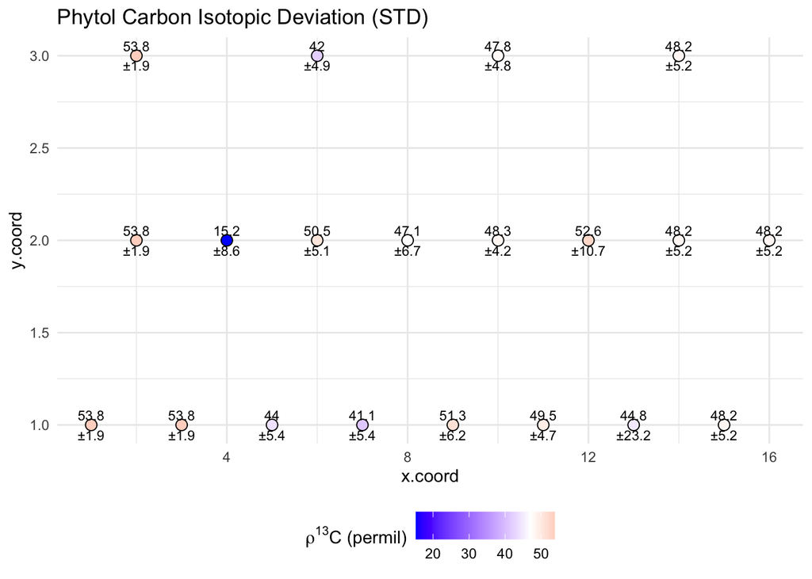

```r
# Molecular plot for STD (Figure STD_2)
atom.13C <- results_df %>%
  group_by(filename) %>%
  mutate(
    mean_ro = mean(ro.13C_est),
    ae_mean = sqrt(sum(ro.13C_ae^2, na.rm = TRUE)) / n(),
    rel.to.averg.value = (ro.13C_est - mean_ro) / mean_ro * 100,
    error.rel.to.averg.value = (100 / mean_ro) *
      sqrt(ro.13C_ae^2 + (ro.13C_est / mean_ro)^2 * ae_mean^2)
  ) %>%
  ungroup() %>%
  filter(filename %in% c("H2210046"))

# Coordinates for molecular plot
atom.13C.coords <- atom.13C %>%
  mutate(
    y.coord = c(2, 1, 2, 1, 2, 1, 2, 1, 2, 1, 2, 1, 2, 1, 2, 1, 3, 3, 3, 3),
    x.coord = c(16:1, 14, 10, 6, 2)
  )

mol <- ggplot(atom.13C.coords,
              aes(x = x.coord, y = y.coord, fill = ro.13C_est * 1000)) +
  geom_point(shape = 21, size = 3) +
  geom_text(aes(label = paste0(
    round(ro.13C_est * 1000, 1), "\n±",
    round(ro.13C_ae * 1000, 1))),
    vjust = 0.5, size = 3) +
  scale_fill_gradient2(low = "blue", mid = "white", high = "red",
                       midpoint = mean(atom.13C.coords$ro.13C_est * 1000),
                       limits = range(atom.13C.coords$ro.13C_est * 1000)) +
  theme_minimal() +
  labs(title = "Phytol Carbon Isotopic Deviation (STD)",
       fill = expression(paste(rho^{13}, "C (permil)"))) +
  theme(legend.position = "bottom")

mol
```

```r
ggsave("output/fig5.STD.pdf", width = 7, height = 5)
```

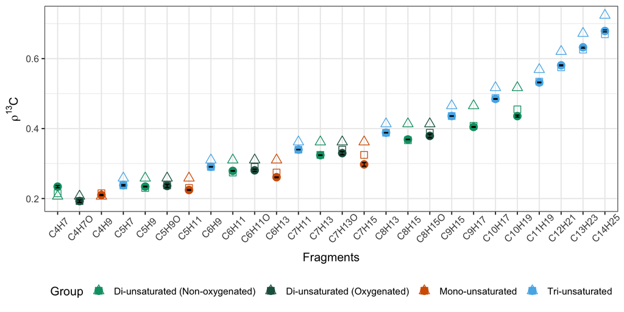

```r
# Calculate fragment sums from position-specific results
fragment_mapping <- tibble(
  fragment = rep(names(fragment_definitions), lengths(fragment_definitions)),
  carbon_position = unlist(fragment_definitions)
)

fragment_sums <- results_df %>%
  inner_join(fragment_mapping, by = "carbon_position", relationship = "many-to-many") %>%
  group_by(filename, ID, fragment) %>%
  summarise(
    ro.13C.hetero = sum(ro.13C_est, na.rm = TRUE),
    .groups = "drop"
  ) %>%
  mutate(fragment = factor(fragment, levels = names(fragment_definitions))) %>%
  arrange(filename, fragment)

# Merge with observed data
results_fragment <- s_ro.corr %>%
  rename(fragment = compound) %>%
  merge(., fragment_sums, by = c("filename", "fragment", "ID")) %>%
  mutate(
    residual = ro.13C.value - ro.13C.hetero,
    relative_error = residual / ro.13C.value,
    DoU = ((2 * n.C + 2) - (n.H + 1)) / 2,
    Group = case_when(
      DoU == 0 ~ "Mono-unsaturated",
      DoU == 1 & grepl("O$", fragment) ~ "Di-unsaturated (Oxygenated)",
      DoU == 1 ~ "Di-unsaturated (Non-oxygenated)",
      DoU == 2 ~ "Tri-unsaturated"
    ),
    element = ifelse(grepl("O", fragment), "O", "C")
  ) %>%
  filter(filename %in% c("H2210046"))

# Figure 4 - Model comparison
level_all <- c("C4H7", "C4H7O", "C4H9", "C5H7", "C5H9", "C5H9O", "C5H11",
               "C6H9", "C6H11", "C6H11O", "C6H13", "C7H11", "C7H13", "C7H13O",
               "C7H15", "C8H13", "C8H15", "C8H15O", "C9H15", "C9H17",
               "C10H17", "C10H19", "C11H19", "C12H21", "C13H23", "C14H25")

plot.data <- results_fragment %>%
  filter(filename %in% c("H2210046"), fragment %in% level_all)

fig4 <- ggplot(plot.data,
       aes(x = factor(fragment, levels = level_all), y = ro.13C.value, colour = Group)) +
  geom_point(size = 3) +
  geom_errorbar(aes(ymin = ro.13C.value - ro.13C.value.ae,
                    ymax = ro.13C.value + ro.13C.value.ae),
                width = 0.2, color = "black") +
  geom_point(aes(y = ro.13C.homo), shape = 2, size = 3) +
  geom_point(aes(y = ro.13C.hetero), shape = 22, size = 3) +
  scale_color_manual(values = c("Mono-unsaturated" = "#D55E00",
                                 "Di-unsaturated (Non-oxygenated)" = "#009E73",
                                 "Di-unsaturated (Oxygenated)" = "#1F604E",
                                 "Tri-unsaturated" = "#56B4E9")) +
  theme_bw() +
  theme(axis.text.x = element_text(angle = 45, vjust = 0.7),
        legend.position = "bottom") +
  labs(x = "Fragments", y = expression(rho^{13}*C))

fig4
```

```r
ggsave("output/fig4.pdf", width = 8, height = 4)
```

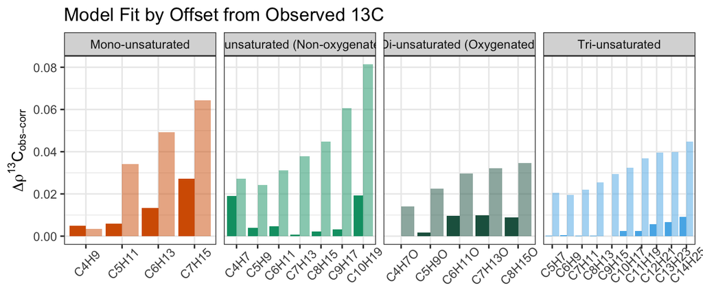

```r
# Figure 4B - Relative differences
rel.diff.results_fragment <- results_fragment %>%
  mutate(
    residual.hetero = ro.13C.value - ro.13C.hetero,
    residual.homo = ro.13C.value - ro.13C.homo
  ) %>%
  select(ID, Group, fragment, ro.13C.value, ro.13C.value.ae,
         ro.13C.homo, ro.13C.hetero, residual.hetero, residual.homo) %>%
  pivot_longer(
    cols = c(residual.hetero, residual.homo),
    names_to = c(".value", "Model"),
    names_pattern = "(residual)\\.(hetero|homo)"
  ) %>%
  rename(Abs_Offset = residual) %>%
  mutate(
    Model = case_when(
      Model == "hetero" ~ "Heterogeneous",
      Model == "homo" ~ "Homogeneous"
    )
  )

fig4b <- ggplot(rel.diff.results_fragment %>%
         filter(ID == "STD", fragment %in% level_all),
       aes(y = abs(Abs_Offset), x = fragment, fill = Group)) +
  geom_bar(stat = "identity", position = position_dodge(width = 0.9),
           aes(alpha = Model)) +
  scale_alpha_manual(values = c("Heterogeneous" = 1, "Homogeneous" = 0.50)) +
  labs(
    title = "Model Fit by Offset from Observed 13C",
    y = expression(Delta*rho^{13}*C[obs-corr]),
    x = "Fragment"
  ) +
  theme_bw() +
  facet_wrap(~ factor(Group, levels = c("Mono-unsaturated",
                                        "Di-unsaturated (Non-oxygenated)",
                                        "Di-unsaturated (Oxygenated)",
                                        "Tri-unsaturated")),
             scales = "free_x", nrow = 1) +
  theme(axis.text.x = element_text(angle = 45, vjust = 0.7),
        axis.title.x = element_blank(),
        legend.position = "none") +
  scale_fill_manual(values = c("#009E73", "#1F604E", "#D55E00", "#56B4E9"))

fig4b
```

```r
ggsave("output/fig4.B.pdf", width = 9, height = 3)
```